# Practical 3 - Exploratory Data Analysis

# Submission: 13 August 2018, 17:30

This practical is based on a dataset containing the prices and other attributes of almost 54,000 diamonds.

```r
library("tidyverse")
library("ggplot2")
library("dplyr")
diamonds
```

```
## # A tibble: 53,940 x 10
##    carat cut       color clarity depth table price     x     y     z
##    <dbl> <ord>     <ord> <ord>   <dbl> <dbl> <int> <dbl> <dbl> <dbl>
##  1 0.23  Ideal     E     SI2      61.5    55   326  3.95  3.98  2.43
##  2 0.21  Premium   E     SI1      59.8    61   326  3.89  3.84  2.31
##  3 0.23  Good      E     VS1      56.9    65   327  4.05  4.07  2.31
##  4 0.290 Premium   I     VS2      62.4    58   334  4.2   4.23  2.63
##  5 0.31  Good      J     SI2      63.3    58   335  4.34  4.35  2.75
##  6 0.24  Very Good J     VVS2     62.8    57   336  3.94  3.96  2.48
##  7 0.24  Very Good I     VVS1     62.3    57   336  3.95  3.98  2.47
##  8 0.26  Very Good H     SI1      61.9    55   337  4.07  4.11  2.53
##  9 0.22  Fair      E     VS2      65.1    61   337  3.87  3.78  2.49
## 10 0.23  Very Good H     VS1      59.4    61   338  4     4.05  2.39
## # ... with 53,930 more rows
```

## Variation

### Question 1 - Discrete variables

1. Visualise the variable ‘cut’ with a bar graph
2. The height of the bars displays how many observations occurred with each x value. Compute these values manually and assign the values to a variable ‘cut_count’

### Answers 1

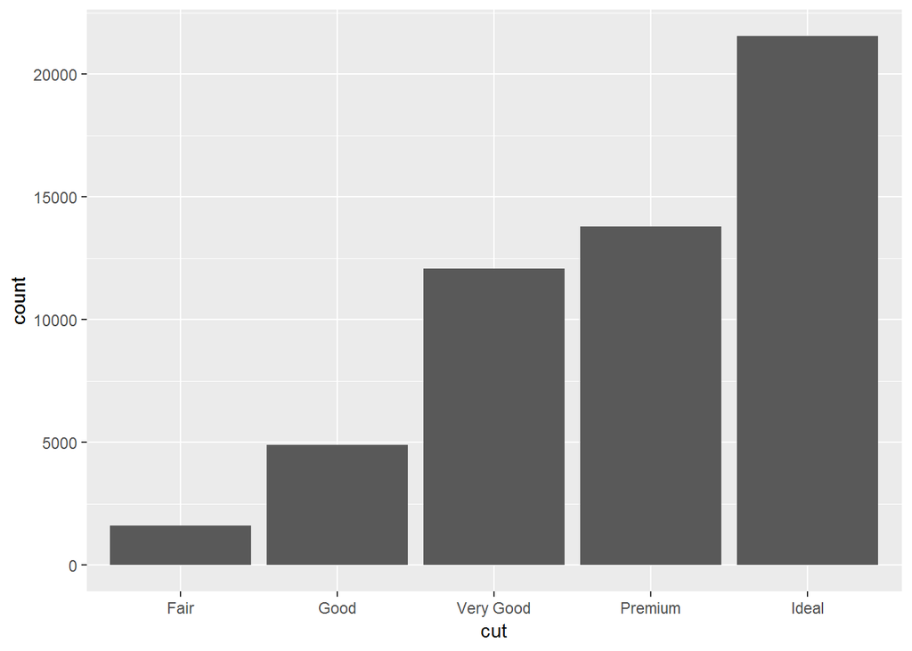

```r
## a. Amount of diamonds per cut type.
ggplot(diamonds,aes(cut)) +
  geom_bar()
```

```r
## b. The manual method to calculate and display the data from above follows below.
summary_b <- diamonds %>% group_by(cut) %>% summarize(cut_count=n())
summary_b
```

```
## # A tibble: 5 x 2
##   cut       cut_count
##   <ord>         <int>
## 1 Fair           1610
## 2 Good           4906
## 3 Very Good     12082
## 4 Premium       13791
## 5 Ideal         21551
```

### Question 2 - Continuous variables

1. Visualise the variable ‘carat’ with a boxplort
2. Visualise the variable ‘carat’ with a histogram using binwidth = 0.5
3. Compute a frequency table of the variable ‘carat’ (with the same binwidth) and assign the values to a variable ‘carat_freq’
4. Filter diamonds with a size of less than three carats. Asign this filtered data to a variable ‘smaller. On the filtered variable ’smaller’:
5. Overlay multiple histograms - one for each cut using geom_freqpoly() which produces line rather than bar histograms. Add a title to the plot.

### Answers 2

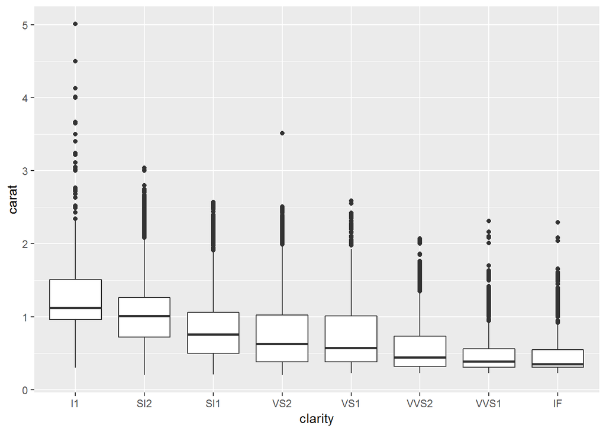

```r
#a. A boxplot representing the interesting relationship between carat and clarity.
ggplot(diamonds,aes(clarity,carat)) +
  geom_boxplot()
```

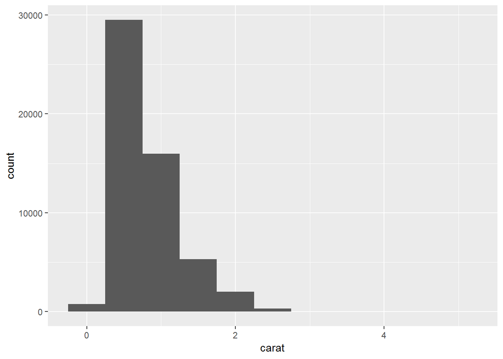

```r
#b. A histogram depicting the amount of diamonds in each 0.5 binwidth carat class.
ggplot(diamonds,aes(carat)) +
  geom_histogram(binwidth=0.5)
```

```r
#c. A frequency table of the carat variable.
binwidth = c(0,0.5,1,1.5,2,2.5,3,3.5,4,4.5,5)
summary_c <- cut(diamonds$carat,breaks=binwidth)
summary_c = factor(summary_c)
table(summary_c)
```

```
## summary_c
## (0,0.5] (0.5,1] (1,1.5] (1.5,2] (2,2.5] (2.5,3] (3,3.5] (3.5,4] (4,4.5]
##   18932   17506   12060    3553    1763      94      23       4       4
```

```r
#d. Filtered data labeled as 'smaller'.
smaller <- filter(diamonds,carat<3)
smaller
```

```
## # A tibble: 53,900 x 10
##    carat cut       color clarity depth table price     x     y     z
##    <dbl> <ord>     <ord> <ord>   <dbl> <dbl> <int> <dbl> <dbl> <dbl>
##  1 0.23  Ideal     E     SI2      61.5    55   326  3.95  3.98  2.43
##  2 0.21  Premium   E     SI1      59.8    61   326  3.89  3.84  2.31
##  3 0.23  Good      E     VS1      56.9    65   327  4.05  4.07  2.31
##  4 0.290 Premium   I     VS2      62.4    58   334  4.2   4.23  2.63
##  5 0.31  Good      J     SI2      63.3    58   335  4.34  4.35  2.75
##  6 0.24  Very Good J     VVS2     62.8    57   336  3.94  3.96  2.48
##  7 0.24  Very Good I     VVS1     62.3    57   336  3.95  3.98  2.47
##  8 0.26  Very Good H     SI1      61.9    55   337  4.07  4.11  2.53
##  9 0.22  Fair      E     VS2      65.1    61   337  3.87  3.78  2.49
## 10 0.23  Very Good H     VS1      59.4    61   338  4     4.05  2.39
## # ... with 53,890 more rows
```

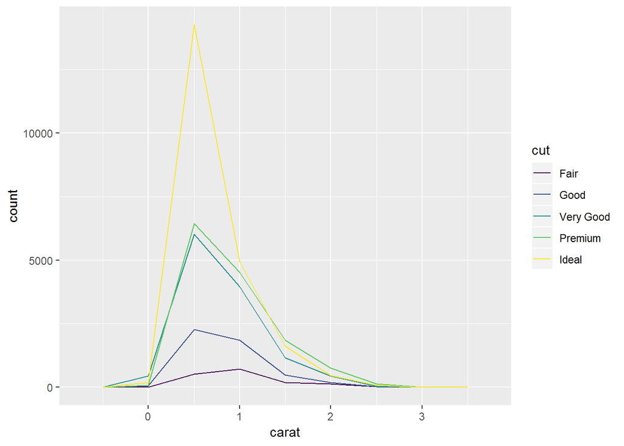

```r
#e. Histograms of carat frequencies for each cut.
ggplot(smaller,aes(carat,colour=cut)) +
  geom_freqpoly(binwidth=0.5)
```

## Covariation

### Question 3 - A categorical and continuous variable

1. Visualise the variable ‘smaller’ for each cut using boxplots. Assign different colorus to each boxplot. Add a title to the plot.
2. Visualise the distribution of price by cut using geom_boxplot(). Assign different colors to each boxplot. Add a title to the plot.

### Answers 3

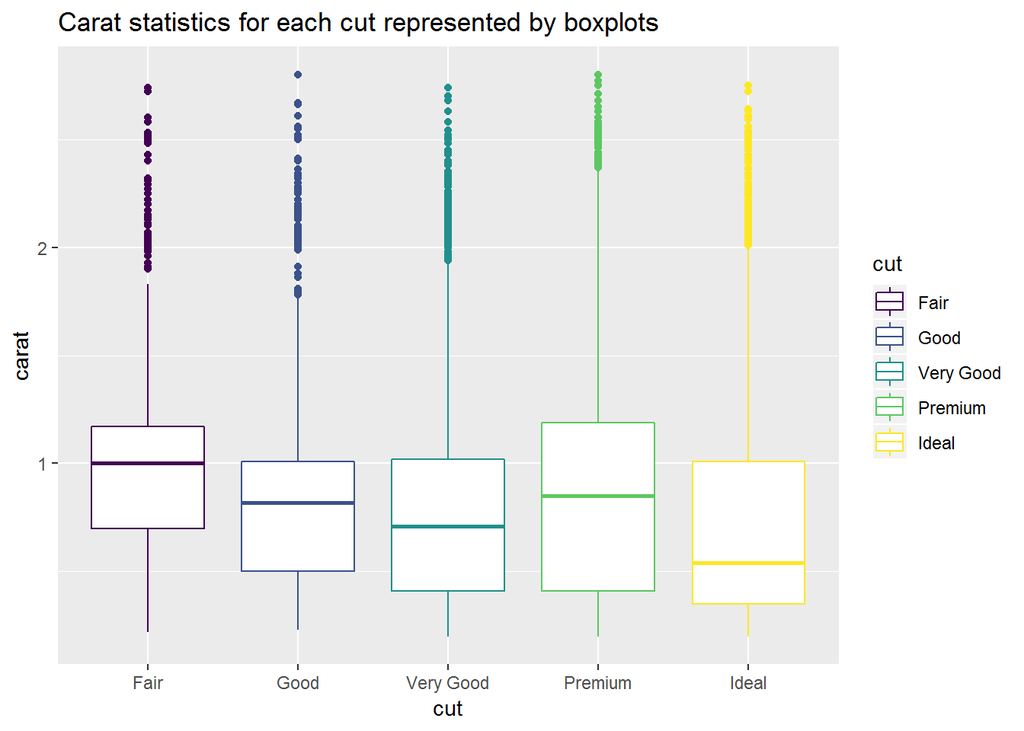

```r
#a. Carat statistics for each cut represented by boxplots.
ggplot(smaller,aes(cut,carat,colour=cut)) +
  geom_boxplot() +
  ggtitle("Carat statistics for each cut represented by boxplots")
```

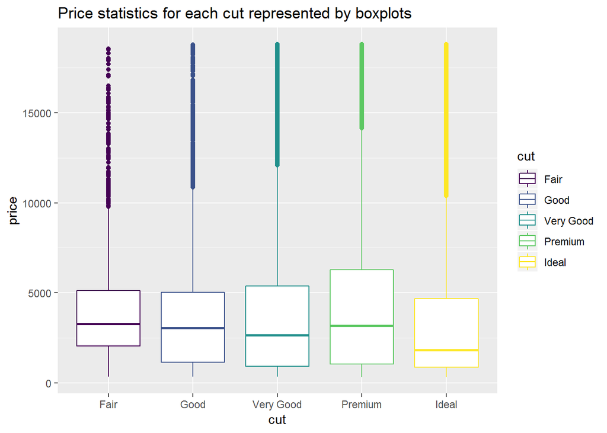

```r
#b. Price statistics for each cut represented by boxplots.
ggplot(smaller,aes(cut,price,colour=cut)) +
  geom_boxplot() +
  ggtitle("Price statistics for each cut represented by boxplots")
```

### Question 4 - Two categorical variables

Consider the following plot of diamond cut vs color (both categorical variables):

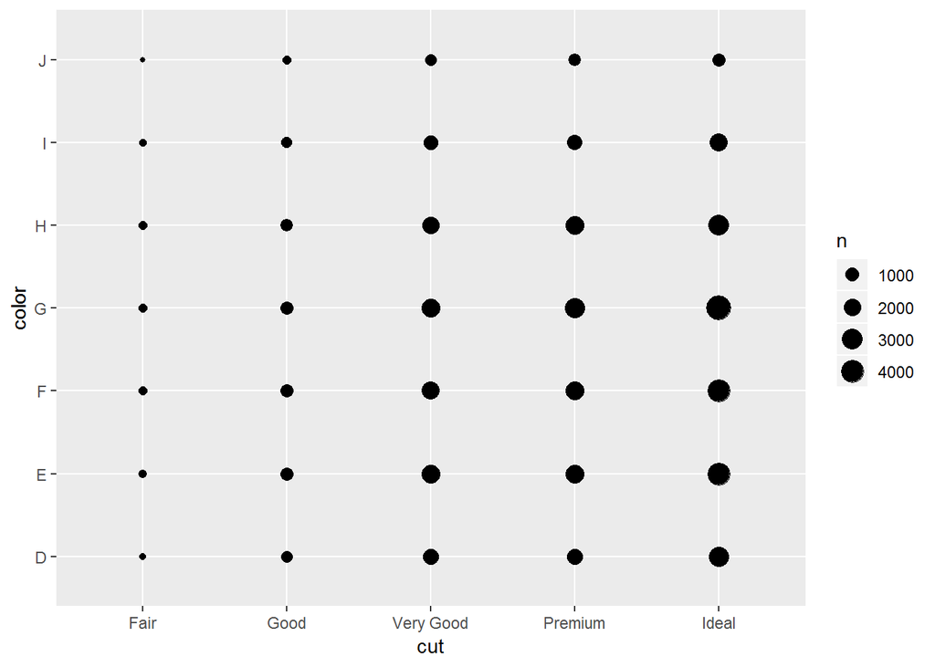

```r
ggplot(data = diamonds) +
  geom_count(mapping = aes(x = cut, y = color))
```

The size of each circle in the plot displays how many observations occurred at each combination of values. Covariation will appear as a strong correlation between specific x values and specific y values.

1. Create an alternative visualisation for these two variables using geom_tile(). Change the colour palette to `spectral’

### Answers 4

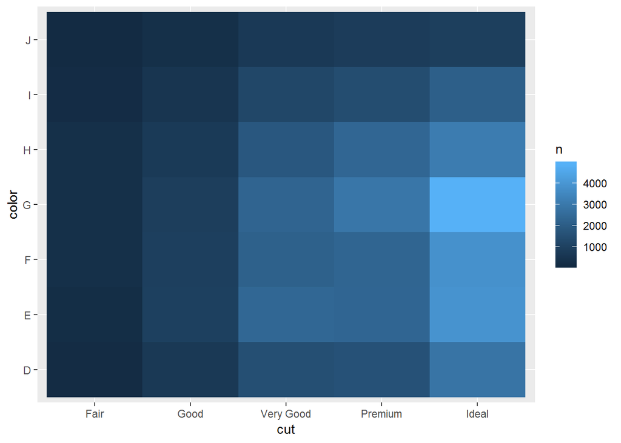

```r
spectral_ds <- diamonds %>% count(cut,color)
ggplot(spectral_ds,aes(cut,color,fill=n)) +
  geom_tile()
```

### Question 5 - Two continuous variables

Visualise price vs carat using geom_boxplot(). - Assign diamond clarity to colour - Reverse the direction of the scale so that the worst diamond clarity is assigned to dark blue and best diamond clarity is assignmed to white. - Make the legend heading ‘Diamond clarity’ - Make the plot background dark for better display

### Answers 5

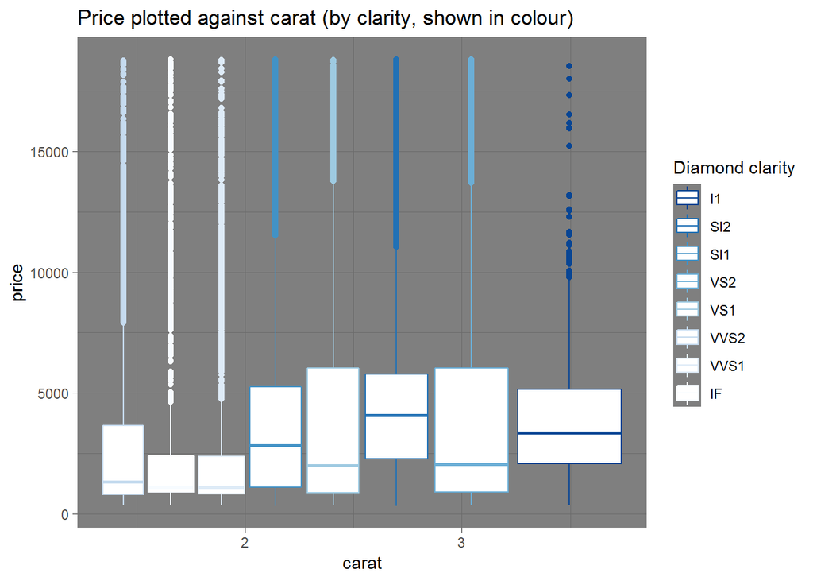

```r
ggplot(diamonds) +
  scale_color_brewer(palette="Blues",direction=-1) +
  geom_boxplot(aes(carat,price,colour=clarity)) +
  labs(colour="Diamond clarity") +
  ggtitle("Price plotted against carat (by clarity, shown in colour)") +
  theme_dark()
```